# Graphs for el prez

```r
library(tidyverse)
```

```r
library(dplyr)
library(ggplot2)
```

## Plots

```r
youtube <- readr::read_csv("https://raw.githubusercontent.com/rfordatascience/tidytuesday/master/data/2021/2021-03-02/youtube.csv")
glimpse(youtube)
```

```
## Rows: 247
## Columns: 25
## $ year                      <dbl> 2018, 2020, 2006, 2018, 2003, 2020, 2020, 20…
## $ brand                     <chr> "Toyota", "Bud Light", "Bud Light", "Hynudai…
## $ superbowl_ads_dot_com_url <chr> "https://superbowl-ads.com/good-odds-toyota/…
## $ youtube_url               <chr> "https://www.youtube.com/watch?v=zeBZvwYQ-hA…
## $ funny                     <lgl> FALSE, TRUE, TRUE, FALSE, TRUE, TRUE, TRUE, …
## $ show_product_quickly      <lgl> FALSE, TRUE, FALSE, TRUE, TRUE, TRUE, FALSE,…
## $ patriotic                 <lgl> FALSE, FALSE, FALSE, FALSE, FALSE, FALSE, FA…
## $ celebrity                 <lgl> FALSE, TRUE, FALSE, FALSE, FALSE, TRUE, TRUE…
## $ danger                    <lgl> FALSE, TRUE, TRUE, FALSE, TRUE, TRUE, FALSE,…
## $ animals                   <lgl> FALSE, FALSE, TRUE, FALSE, TRUE, TRUE, TRUE,…
## $ use_sex                   <lgl> FALSE, FALSE, FALSE, FALSE, TRUE, FALSE, FAL…
## $ id                        <chr> "zeBZvwYQ-hA", "nbbp0VW7z8w", "yk0MQD5YgV8",…
## $ kind                      <chr> "youtube#video", "youtube#video", "youtube#v…
## $ etag                      <chr> "rn-ggKNly38Cl0C3CNjNnUH9xUw", "1roDoK-SYqSp…
## $ view_count                <dbl> 173929, 47752, 142310, 198, 13741, 23636, 30…
## $ like_count                <dbl> 1233, 485, 129, 2, 20, 115, 1470, 78, 342, 7…
## $ dislike_count             <dbl> 38, 14, 15, 0, 3, 11, 384, 6, 7, 0, 14, 0, 2…
## $ favorite_count            <dbl> 0, 0, 0, 0, 0, 0, 0, 0, 0, 0, 0, 0, 0, 0, 0,…
## $ comment_count             <dbl> NA, 14, 9, 0, 2, 13, 227, 6, 30, 0, 8, 1, 13…
## $ published_at              <dttm> 2018-02-03 11:29:14, 2020-01-31 21:04:13, 2…
## $ title                     <chr> "Toyota Super Bowl Commercial 2018 Good Odds…
## $ description               <chr> "Toyota Super Bowl Commercial 2018 Good Odds…
## $ thumbnail                 <chr> "https://i.ytimg.com/vi/zeBZvwYQ-hA/sddefaul…
## $ channel_title             <chr> "Funny Commercials", "VCU Brandcenter", "Joh…
## $ category_id               <dbl> 1, 27, 17, 22, 24, 1, 24, 2, 24, 24, 24, 24,…
```

### Question 1 hi

To address Question 1, we will first have to create a new variable that counts the occurrence of different content types for each year in the dataset. There are 7 different content types (funny, show_product_quickly, patriotic, celebrity, danger, animals, or use_sex) and so we will generate 7 new variables (funny_count, show_product_quickly_count, patriotic_count, celebrity_count, danger_count, animals_count, use_sex_count) that count the occurrence of each of these content tags. For example, if there are 7 commercials in 2000 that are tagged as funny, the new variable funny_count will equal 7 for that year. Videos that do not have content tags will be completely omitted from the analysis.

```r
youtube <- youtube %>%
  group_by(year) %>%
  summarise(funny_count = sum(funny),
            show_product_quickly_count = sum(show_product_quickly),
            patriotic_count = sum(patriotic),
            celebrity_count = sum(celebrity),
            danger_count = sum(danger),
            animals_count = sum(animals),
            use_sex_count = sum(use_sex)) %>%
  pivot_longer(cols = c(funny_count, show_product_quickly_count, patriotic_count, celebrity_count, danger_count, animals_count, use_sex_count), names_to = "type")

youtube
```

```
## # A tibble: 147 × 3
##     year type                       value
##    <dbl> <chr>                      <int>
##  1  2000 funny_count                    8
##  2  2000 show_product_quickly_count     5
##  3  2000 patriotic_count                0
##  4  2000 celebrity_count                0
##  5  2000 danger_count                   4
##  6  2000 animals_count                  4
##  7  2000 use_sex_count                  1
##  8  2001 funny_count                   10
##  9  2001 show_product_quickly_count     4
## 10  2001 patriotic_count                1
## # … with 137 more rows
```

line graph of content type prevalency over time

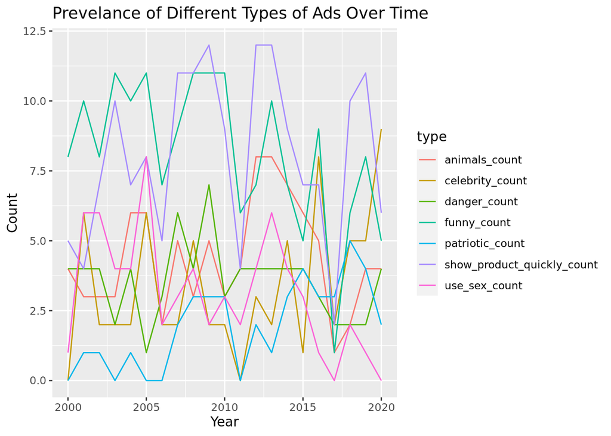

```r
ggplot(data = youtube, aes(x = year, y = value, color = type)) +
  geom_line() +
  labs(title = "Prevelance of Different Types of Ads Over Time", x = "Year", y = "Count")
```

The second plot will be a deep dive into one content area. After creating the first plot and conducting a simple analysis, we will choose a content area that has an interesting trend (prevalence has increased / decreased significantly, prevalence fluctuates significantly, etc.). For all the videos that contain the category we choose, we will use geom_point to look at the relationship between like_count (x-axis) and view_count (y-axis). In addition, we will color the observations by brand to see if there is any interaction there with respect to this relationship. This way we can identify any brands that have unique relationships between like_counts and view_counts in the content area of our choosing, which may help explain whatever pattern we originally identify.

Based on our first plot, we found that danger_count, show_product_quickly_count, and celebrity count had interesting trends. We will do a deep dive into these categories to explore the relationship between like_count and view count.

```r
ya_youtube <- readr::read_csv("https://raw.githubusercontent.com/rfordatascience/tidytuesday/master/data/2021/2021-03-02/youtube.csv")
ya_youtube %>%
  filter(show_product_quickly  == TRUE,
         danger == TRUE,
         celebrity == TRUE)
```

```
## # A tibble: 12 × 25
##     year brand     superbowl_ads_d… youtube_url funny show_product_qu… patriotic
##    <dbl> <chr>     <chr>            <chr>       <lgl> <lgl>            <lgl>
##  1  2020 Bud Light https://superbo… https://ww… TRUE  TRUE             FALSE
##  2  2020 Toyota    https://superbo… https://ww… TRUE  TRUE             FALSE
##  3  2020 Budweiser https://superbo… https://ww… FALSE TRUE             TRUE
##  4  2020 Doritos   https://superbo… https://ww… TRUE  TRUE             FALSE
##  5  2016 Coca-Cola https://superbo… https://ww… TRUE  TRUE             FALSE
##  6  2015 Kia       https://superbo… https://ww… TRUE  TRUE             FALSE
##  7  2014 Hynudai   https://superbo… https://ww… TRUE  TRUE             FALSE
##  8  2013 Bud Light https://superbo… https://ww… TRUE  TRUE             TRUE
##  9  2009 Coca-Cola https://superbo… https://ww… TRUE  TRUE             FALSE
## 10  2008 Coca-Cola https://superbo… https://ww… TRUE  TRUE             FALSE
## 11  2006 Pepsi     https://superbo… https://ww… TRUE  TRUE             FALSE
## 12  2002 Bud Light https://superbo… https://ww… TRUE  TRUE             FALSE
## # … with 18 more variables: celebrity <lgl>, danger <lgl>, animals <lgl>,
## #   use_sex <lgl>, id <chr>, kind <chr>, etag <chr>, view_count <dbl>,
## #   like_count <dbl>, dislike_count <dbl>, favorite_count <dbl>,
## #   comment_count <dbl>, published_at <dttm>, title <chr>, description <chr>,
## #   thumbnail <chr>, channel_title <chr>, category_id <dbl>
```

[figure not shown]

```r
ggplot(data = ya_youtube, aes(x = like_count, y = view_count, color = brand)) +
  geom_point() +
  labs(title = "Proportion of Likes/Dislikes Over time for ads containing danger,
       celebrities, and shows_product_quickly", x = "Like_Count", y = "View_Count") + theme_minimal()
```

### Question 2

```r
youtube <- readr::read_csv("https://raw.githubusercontent.com/rfordatascience/tidytuesday/master/data/2021/2021-03-02/youtube.csv")
q2_part1_data <- filter(youtube, like_count != is.na(like_count) &
                          dislike_count != is.na(dislike_count)) %>%
  group_by(brand) %>%
  mutate(likes_total = sum(like_count),
         dislikes_total = sum(dislike_count),
         proportion_likes_total = likes_total / (dislikes_total + likes_total))

q2_part2_data <- youtube %>%
  group_by(brand) %>%
  group_by(year) %>%
  mutate(proportion_likes_yearly = like_count / sum(like_count,
                                                    dislike_count))
```

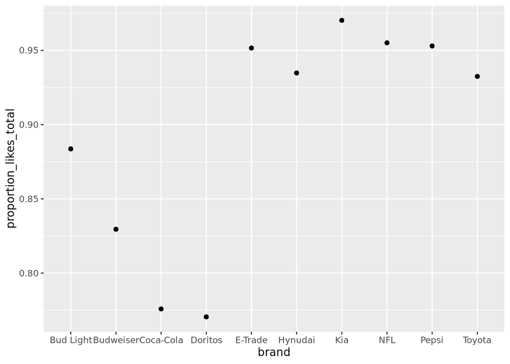

```r
ggplot(q2_part1_data, aes(x = brand, y = proportion_likes_total)) +
  geom_point()
```

Based on our findings in the previous analysis the top 3 brands are kia, nfl, and pesi.

Both of our questions use the variables in the original dataset: Superbowl Ads. Therefore, we do not need to merge any external data.

```r
youtube2 <- readr::read_csv("https://raw.githubusercontent.com/rfordatascience/tidytuesday/master/data/2021/2021-03-02/youtube.csv")
youtube2 <- youtube2 %>%
  filter(brand == c("Kia", "NFL", "Pepsi", "E-Trade"))%>%
  group_by(year, brand) %>%
  summarise(total_dislikes = sum(dislike_count),
            total_likes = sum(like_count))
youtube2 <- youtube2 %>%
  mutate(proportion_likes_yearly = total_likes / (total_likes + total_dislikes))

youtube2
```

```
## # A tibble: 15 × 5
## # Groups:   year [11]
##     year brand   total_dislikes total_likes proportion_likes_yearly
##    <dbl> <chr>            <dbl>       <dbl>                   <dbl>
##  1  2001 E-Trade              7         167                   0.960
##  2  2001 Pepsi                4         109                   0.965
##  3  2004 Pepsi                9         222                   0.961
##  4  2005 Pepsi                0           0                 NaN
##  5  2006 Pepsi                7          70                   0.909
##  6  2009 Pepsi                0           7                   1
##  7  2010 E-Trade              1          19                   0.95
##  8  2010 NFL                 14         404                   0.967
##  9  2011 Kia                  7         200                   0.966
## 10  2012 Kia                  5         396                   0.988
## 11  2012 NFL                 42        1980                   0.979
## 12  2013 E-Trade              0           1                   1
## 13  2018 Kia                  3         219                   0.986
## 14  2019 Kia                 NA          NA                  NA
## 15  2019 Pepsi               52        1734                   0.971
```

[figure not shown]

```r
ggplot(data = youtube2, aes(x = year, y = proportion_likes_yearly, color = brand)) +
  geom_point() +
  labs(title = "Proportion of Likes/Dislikes over time for the top 3 Brands", x = "Year", y = "Count") + theme_minimal()
```